# QTM 151 - Practice Quiz

**Submit as an HTML file** (see images below)

Step 1: Click the 3 dots in the toolbar for "More Actions"

[figure not shown]

Step 2: Choose "export"

[figure not shown]

Step 3: Select "HTML" from the dropdown window

[figure not shown]

Step 4: Select "Export" in the pop-up window.

[figure not shown]

Upload the .html file as your submission

Print your name below

```python
# Write your answer here

print("Jongyun Shin")
```

```
Jongyun Shin
```

This quiz is open book

- You can use the lecture notes
- You will get partial credit for attempting the questions
- To get full credit, the code should work as intended
- You should NOT communicate with other students

Print the following message:

"I will abide by Emory's code of conduct"

```python
# Write your answer here:
print("I will abide by Emory's code of conduct" )
```

```
I will abide by Emory's code of conduct
```

Load in any necessary libraries/packages below:

```python
# load in necessary packages/libraries

import numpy as np
import matplotlib.pyplot as plt
import pandas as pd
```

Preliminary check: can you load the data?

In the .zip file you opened, there is a comma-separated values file named  
"HeightWeight-quiz.csv". Using Pandas, create a DataFrame object by reading in this file.

If you get an error, you must figure out what the issue is.

**Note**: This cell is just to test whether you can access the data correctly. If everything works, you can copy and paste the code later in the notebook if you prefer.

```python
# create a DataFrame by loading in the data
# You will need this for questions later.

heightweight_df = pd.read_csv('data_folder/HeightWeight-quiz.csv')
```

(a) Making changes to a for loop

How would you change the code below, so that it prints out the position in the list of each non-numerical item it encounters?

Implement those changes, and run the code cell

```python
### Make changes to the code below

list_mixed = [1, 2, None, None, 4, 11, "Apple", 2.2, 13, "!!!", None]

list_sum = 0
index=0 #keep track of index position

for value in (list_mixed):
    if (type(value) != int) and (type(value) != float):
        print("Warning: Non-numerical element in position", index , "of list!")
        index = index + 1 # move to next index position
        continue

    list_sum = list_sum + value
    index = index + 1 # move to next index position

print(list_sum)
```

[output not shown]

(b) Debugging code

Below is a code which attempts to compute the sum $$1 + 2 + 3 + \cdots + (n-1) + n$$ for a positive integer $n$. For this example, we set $n = 10$. In this case, we would expect the output to be: $$ 1 + 2 + 3 + \cdots + 9 + 10 = \frac{10\times 11}{2} = 55$$

but that is not what is printed out when we run the cell below. Find the error in the code, and fix it. Then re-run the cell with $n = 19$, which should print the number $$ \frac{19\times 20}{2} = 190$$

```python
# Find the error and fix it.
# Then run the cell after setting n = 19
n = 10

sum_n = 0
for summands in range(n):
    sum_n = sum_n + summands
    sum_n = sum_n+ 1
print(sum_n)


# Now set n = 19 and run the cell again.
n = 19
sum_n = 0
for summands in range(n):
    sum_n = sum_n + summands
    sum_n = sum_n+ 1
print(sum_n)
print()
# method 2
sum_n = 0
for summands in range(1,n+1): # change to range(1, n+1)
    sum_n = sum_n + summands

print(sum_n)
print()

# method 3
sum_n = 0
for terms in range(n):
    summand = terms + 1 # add 1 so it doesn't start at zero
    sum_n = sum_n + summand
print(sum_n)
```

```
55
190

190

190
```

c) Extracting and sorting subsets of data

In the .zip file you opened, there is a comma-separated values file named  
"HeightWeight-quiz.csv". Using Pandas, create a DataFrame object by reading in this file.

Extract rows 345 through 397 (that is, all the rows 345, 346, 347, ..., 396, 397) of the DataFrame, saving it as another DataFrame. Then sort this subset by Height (lowest to highest), assigning it to a DataFrame called `subset_sorted`

```python
# Write your answer here:

subset_so = heightweight_df.iloc[345:397,:]

subset_sorted= subset_so.sort_values(by="Height_Inches", ascending=True)
print(subset_sorted)
```

```
     Index  Height_Inches  Weight_Pounds
394    395       63.76881       119.3691
359    360       64.18633       118.4759
377    378       64.66007       108.6044
369    370       65.72927       131.8008
378    379       65.73721       100.6617
384    385       66.04157       127.8822
360    361       66.09074       129.5516
392    393       66.44873       118.9856
387    388       66.46042       124.5581
346    347       66.46536       121.5515
396    397       66.48966       126.6122
370    371       66.49627       122.8561
353    354       67.13983       131.5906
372    373       67.37579       142.6929
```

[output cut: 38 more lines]

(d) Filtering a data set

Create two DataFrames containing the following subsets of the data:

- People who weight satisfies $115 \leq \textrm{weight} \leq 140$ (in pounds)
- People who either i) weigh strictly less than 95 pounds **or** ii) are 72 inches or taller (greater than or equal to 72 inches)

```python
# Write your answer here:

df115_w_140 = heightweight_df.query("115 <= Weight_Pounds <= 140")
df115_w_140_sorted = df115_w_140.sort_values(by="Weight_Pounds", ascending=False)
print(df115_w_140_sorted)
```

```
       Index  Height_Inches  Weight_Pounds
14913  14914       67.44849       139.9993
15        16       71.09160       139.9975
24117  24118       70.04973       139.9917
16715  16716       70.06553       139.9915
16054  16055       68.54234       139.9910
...      ...            ...            ...
13808  13809       67.54977       115.0079
12854  12855       66.31944       115.0054
7409    7410       65.14364       115.0040
8232    8233       68.18063       115.0030
3869    3870       68.21154       115.0009

[17965 rows x 3 columns]
```

```python
df_95lb_72in = heightweight_df.query("Weight_Pounds < 95 or Height_Inches >= 72")
print(df_95lb_72in)
```

```
       Index  Height_Inches  Weight_Pounds
138      139       73.90107      151.39130
154      155       72.44434      136.73970
158      159       72.01515      138.77580
174      175       73.83364      139.29830
234      235       72.74676      135.74580
...      ...            ...            ...
24801  24802       74.53177      148.91040
24835  24836       65.17339       94.40946
24883  24884       73.06241      141.50540
24921  24922       72.54953      134.51430
24939  24940       72.35889      143.95470

[505 rows x 3 columns]
```

(e) Random Assignment

We want to divide the dataset into 3 groups randomly: group A, group B, group C

Randomly assign each person in the dataset one of three possible strings: `"A"`, `"B"`, or `"C"`. Add a column/variable to the DataFrame which contains the letter each person is assigned. Give the column/variable the name `"Group"`

**Hint**: Randomly choosing among 3 strings is not much different from randomly choosing among 4 numbers, which is what we did in Lecture 11

```python
# Write your answer here:

import numpy as np

# get number of rows in your dataset
num_rows = heightweight_df.shape[0]

# randomly assign each person to group A, B, or C
heightweight_df["Group"] = np.random.choice(["A", "B", "C"], size=num_rows)

# check the first few rows to confirm
print(heightweight_df.head())


#or

nrows, ncols = heightweight_df.shape

rand_ID = np.random.choice(["A", "B", "C"], size = nrows)

heightweight_df["Group"] = rand_ID
```

```
   Index  Height_Inches  Weight_Pounds Group
0      1       65.78331       112.9925     C
1      2       71.51521       136.4873     A
2      3       69.39874       153.0269     B
3      4       68.21660       142.3354     A
4      5       67.78781       144.2971     A
```

(f) Plotting data from one the groups

Create a new DataFrame by extracting all rows corresponding to Group B. Then make a scatter plot of height vs. weight (height on horizontal axis, weight on vertical axis) for the people in this group.

Give appropriate labels to the axes and give your scatter plot a reasonable title.

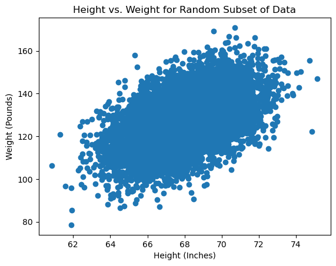

```python
group_B = heightweight_df.query("Group == 'B'")

plt.scatter(x = group_B["Height_Inches"], y = group_B["Weight_Pounds"])
plt.xlabel("Height (Inches)")
plt.ylabel("Weight (Pounds)")
plt.title("Height vs. Weight for Random Subset of Data")
plt.show()
```

(g) Convert your notebook to .html

Convert your notebook to .html format. You will be expected to submit your quiz in this format, so now is the time to make sure you can do it. Instructions are at the top of this notebook.

**A small point deduction will be taken off for submissions in the wrong format**